# Project 3

## Setup and imports

```python
import pandas as pd
import matplotlib.pyplot as plt
import numpy as np
from sklearn import preprocessing, svm
from sklearn.model_selection import train_test_split
from sklearn.linear_model import LinearRegression
from statsmodels.formula.api import ols


# importing data
df = pd.read_csv("mirror/gap.tsv", sep='\t')
df.head()
```

|  | country | continent | year | lifeExp | pop | gdpPercap |
| --- | --- | --- | --- | --- | --- | --- |
| 0 | Afghanistan | Asia | 1952 | 28.801 | 8425333 | 779.445314 |
| 1 | Afghanistan | Asia | 1957 | 30.332 | 9240934 | 820.853030 |
| 2 | Afghanistan | Asia | 1962 | 31.997 | 10267083 | 853.100710 |
| 3 | Afghanistan | Asia | 1967 | 34.020 | 11537966 | 836.197138 |
| 4 | Afghanistan | Asia | 1972 | 36.088 | 13079460 | 739.981106 |

## Part 1

### Exercise 1

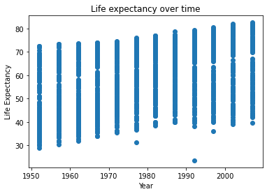

```python
# Creating plot
fig, ax = plt.subplots()
# Setting labels
ax.set_ylabel("Life Expectancy")
ax.set_xlabel("Year")
ax.set_title("Life expectancy over time")
# Plotting year by life expectancy
ax.scatter(df["year"],df["lifeExp"])
fig.show()
```

### Question 1

#### The average life expectancy across countries is generally increasing with time. This trend seems to be linear.

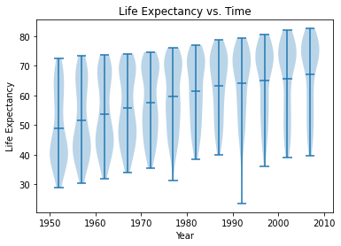

```python
# Constructing Violin Plot
fig, ax = plt.subplots()
# getting year data
years = df["year"].unique()
# getting all data for each year
life_exp_per_year = []
df.groupby("year").apply(lambda x: life_exp_per_year.append(x["lifeExp"]))
# constructing plot
ax.violinplot(life_exp_per_year,years,widths=4,showmeans=True)
# setting labels and title
ax.set_xlabel("Year")
ax.set_ylabel("Life Expectancy")
ax.set_title("Life Expectancy vs. Time")
fig.show()
```

### Question 4

#### I think the data would be skewed upwards since, on average, the majority of unimodal years have a mode above the mean.

### Question 5

#### Ideally, the violin plot should be unimodal where the mode approaches the mean. In the best case scenario, the mean residuals are close to 0.

### Exercise 2

```python
# Removing null data
df2 = df.fillna(method ='ffill')

# Getting arrays for training data
lifeExp = np.array(df2['lifeExp'])
year = np.array(df2['year']).reshape(-1, 1)

# Creating linear regression
regr = LinearRegression()
regr.fit(year,lifeExp)

# Printing out relevant information
print("Intercept:", regr.intercept_)
print("Coefficient:", regr.coef_[0])
```

```
Intercept: -585.6521874415448
Coefficient: 0.3259038276371518
```

### Question 6

#### Life expectancy increases by about 0.32 of a year each year.

### Question 7

#### I reject the null hypothesis because the regression shows a positive correlation between life expectancy and year.

### Exercise 3

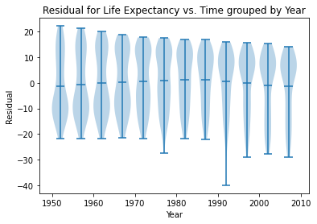

```python
# Find the predictions for each year and use them to calculate and save the corresponding residual
prediction = regr.predict(np.array(df["year"]).reshape(-1,1))
df["residual"] = df["lifeExp"] - prediction

# getting years and correspsonding residual
years = df["year"].unique()
life_exp_per_year_residual = []
df.groupby("year").apply(lambda x: life_exp_per_year_residual.append(x["residual"]))

# Constructing the plot
fig, ax = plt.subplots()
ax.violinplot(life_exp_per_year_residual,years,widths=4,showmeans=True)
# setting labels and title
ax.set_xlabel("Year")
ax.set_ylabel("Residual")
ax.set_title("Residual for Life Expectancy vs. Time grouped by Year")
fig.show()
```

### Question 8

#### This plot matches my expectations from what I predicted in Question 4. The modes are mostly greater than the means.

### Exercise 4

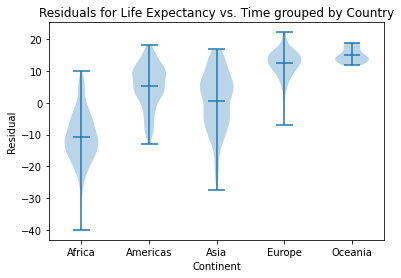

```python
# getting continents and correspsonding residual
continents = [1,2,3,4,5]
life_exp_per_continent_residual = []
df.groupby("continent").apply(lambda x: life_exp_per_continent_residual.append(x["residual"]))

# Constructing the plot
fig, ax = plt.subplots()
ax.violinplot(life_exp_per_continent_residual,continents,showmeans=True)
# setting labels and title
ax.set_xlabel("Continent")
ax.set_ylabel("Residual")
ax.set_title("Residuals for Life Expectancy vs. Time grouped by Country")
ax.set_xticks(continents)
ax.set_xticklabels(['Africa', 'Americas', 'Asia', 'Europe', 'Oceania'])
fig.show()
```

### Question 9

#### Since all of the different countinents have pretty different residuals, it seems that the model is dependent on continent.

#### The regression isn't entirely correct since there is another variable at play we do not account for.

### Exercise 5

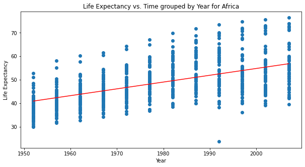

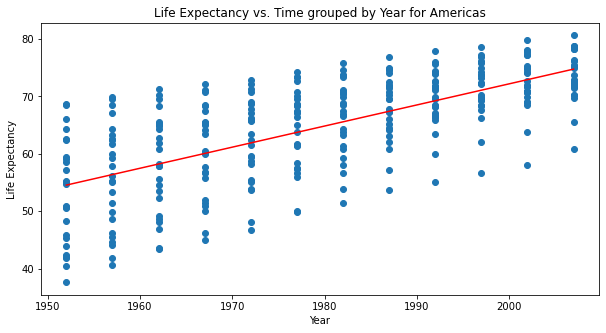

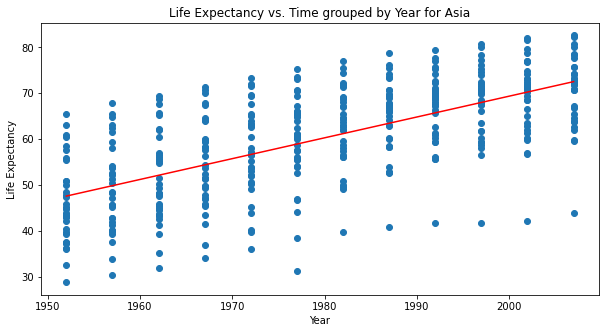

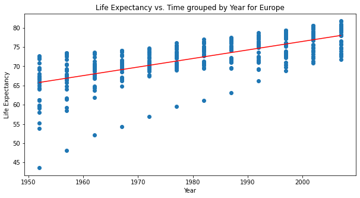

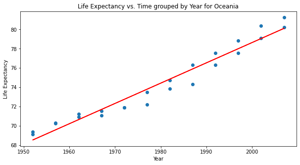

```python
# Create a function to plot scatter plot for continent and find and plot regression line
def plot(x_axis,y_axis,name):
    # find the regression line for the group
    m, b = np.polyfit(x_axis, y_axis, 1)

    # construct the plot
    fig, ax = plt.subplots(figsize=(10,5))
    # plot the points for the scatter plot
    ax.scatter(x_axis,y_axis)
    # plot the regression lin
    ax.plot(x_axis, (m*np.array(x_axis)+b), "-", color="red", label='_nolegend_')
    # set labels and title
    ax.set_xlabel("Year")
    ax.set_ylabel("Life Expectancy")
    ax.set_title("Life Expectancy vs. Time grouped by Year for "+name)
    plt.show()

# apply function to each continent in group
df.groupby("continent").apply(lambda x: plot(x["year"],x["lifeExp"],x.name))
```

### Question 10

#### Our model should include an interaction term for continent and year since life expectancy is vastly different across continents.

### Exercise 6

```python
# Creating regression using continent and year
formula = "lifeExp ~ (df[\"continent\"]) + (df[\"year\"]) + ((df[\"continent\"]) * (df[\"year\"]))"
ols_model = ols(formula, df).fit()
ols_model.summary()
```

OLS Regression Results

| Dep. Variable: | lifeExp | R-squared: | 0.693 |
| --- | --- | --- | --- |
| Model: | OLS | Adj. R-squared: | 0.691 |
| Method: | Least Squares | F-statistic: | 424.3 |
| Date: | Tue, 29 Nov 2022 | Prob (F-statistic): | 0.00 |
| Time: | 22:14:05 | Log-Likelihood: | -5771.9 |
| No. Observations: | 1704 | AIC: | 1.156e+04 |
| Df Residuals: | 1694 | BIC: | 1.162e+04 |
| Df Model: | 9 |  |  |
| Covariance Type: | nonrobust |  |  |

|  | coef | std err | t | P>\|t\| | [0.025 | 0.975] |
| --- | --- | --- | --- | --- | --- | --- |
| Intercept | -524.2578 | 32.963 | -15.904 | 0.000 | -588.911 | -459.605 |
| df["continent"][T.Americas] | -138.8484 | 57.851 | -2.400 | 0.016 | -252.315 | -25.382 |
| df["continent"][T.Asia] | -312.6330 | 52.904 | -5.909 | 0.000 | -416.396 | -208.870 |
| df["continent"][T.Europe] | 156.8469 | 54.498 | 2.878 | 0.004 | 49.957 | 263.737 |
| df["continent"][T.Oceania] | 182.3499 | 171.283 | 1.065 | 0.287 | -153.599 | 518.298 |
| df["year"] | 0.2895 | 0.017 | 17.387 | 0.000 | 0.257 | 0.322 |
| df["continent"][T.Americas]:df["year"] | 0.0781 | 0.029 | 2.673 | 0.008 | 0.021 | 0.135 |
| df["continent"][T.Asia]:df["year"] | 0.1636 | 0.027 | 6.121 | 0.000 | 0.111 | 0.216 |
| df["continent"][T.Europe]:df["year"] | -0.0676 | 0.028 | -2.455 | 0.014 | -0.122 | -0.014 |
| df["continent"][T.Oceania]:df["year"] | -0.0793 | 0.087 | -0.916 | 0.360 | -0.249 | 0.090 |

| Omnibus: | 27.121 | Durbin-Watson: | 0.242 |
| --- | --- | --- | --- |
| Prob(Omnibus): | 0.000 | Jarque-Bera (JB): | 44.106 |
| Skew: | -0.121 | Prob(JB): | 2.65e-10 |
| Kurtosis: | 3.750 | Cond. No. | 2.09e+06 |

Notes:  
[1] Standard Errors assume that the covariance matrix of the errors is correctly specified.  
[2] The condition number is large, 2.09e+06. This might indicate that there are  
strong multicollinearity or other numerical problems.

#### NOTE Africa is represented in the df["year"] column and everything is with respect to Africa

### Question 11

#### No, they aren't all signifcantly different from zero since Oceania's parameter has a 28.7% chance of not being statiscially significant.

### Question 12

#### Code to find life expectancy coefficient

```python
def find_models_by_continent(lifeExp,year,continent):
    lifeExp = np.array(lifeExp)
    year = np.array(year).reshape(-1, 1)
    regr = LinearRegression()
    regr.fit(year,lifeExp)
    print(continent)
    print("Coefficient:", regr.coef_[0])
df.groupby("continent").apply(lambda x: find_models_by_continent(x["lifeExp"],x["year"],x.name))
```

```
Africa
Coefficient: 0.28952926304464766
Americas
Coefficient: 0.3676509370629371
Asia
Coefficient: 0.4531224038991313
Europe
Coefficient: 0.22193214452214463
Oceania
Coefficient: 0.21027237762237763
```

#### Life expectancy increases by 0.29 of a year in Africa

#### Life expectancy increases by 0.37 of a year in the Americas

#### Life expectancy increases by 0.45 of a year in Asia

#### Life expectancy increases by 0.22 of a year in Europe

#### Life expectancy increases by 0.21 of a year in Oceania

### Exercise 7

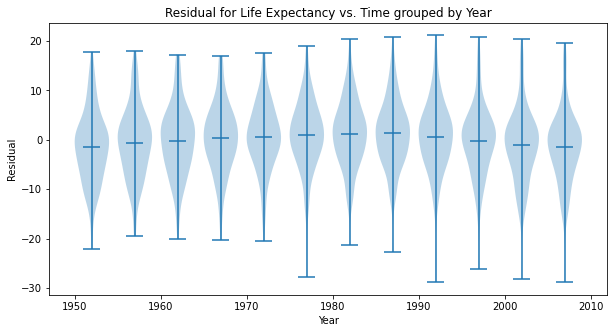

```python
# Find the predictions from our model
predictions = ols_model.predict()

# find and save the residuals
df["residualOLS"] = df["lifeExp"] - predictions
years = df["year"].unique()
life_exp_per_year_cont = []
df.groupby("year").apply(lambda x: life_exp_per_year_cont.append(x["residualOLS"]))

# Construct the plot
fig, ax = plt.subplots(figsize=(10,5))
ax.violinplot(life_exp_per_year_cont,years,widths=4,showmeans=True)
ax.set_xlabel("Year")
ax.set_ylabel("Residual")
ax.set_title("Residual for Life Expectancy vs. Time grouped by Year")
plt.show()
```

#### This violin plot matches the expectations we had for the linear regression model. We see that it is completely unimodal with the mode focused around the mean, at 0.

## Part 2

### I am using a breast cancer dataset that has 30 features about samples taken. It contains whether the sample is malignant or benign. I will be using decision tree and random forest classifiers.

### Code to pull dataset

```python
from sklearn import datasets
breast_cancer = datasets.load_breast_cancer()
```

### Decision Tree - I chose a decision tree classifier since this is a simple binary classification between malignant or benign

### Code to fit decision tree and using holdout validation to find the accuracy of the model.

```python
# Import decision tree classifier class
from sklearn import tree
decision_tree = tree.DecisionTreeClassifier()

# Split our data into train and test sets using holdout validation
var_train, var_test, res_train, res_test = train_test_split(breast_cancer.data, breast_cancer.target)

# Fit the data using the train_test_split
decision_tree = decision_tree.fit(var_train, res_train)

# Find and print the accuracy
print(decision_tree.score(var_test, res_test)*100)
```

```
91.6083916083916
```

#### The decision tree model had an accuracy of 91.6%.

### Random Forest - I chose a random forest classifier since this data lends itself well to decision trees already, and random forests are an extension of decision trees

### Code to fit random forest and using holdout validation to find the accuracy of the model.

```python
# Import random forest classifier class
from sklearn import ensemble
forest = ensemble.RandomForestClassifier()

# Split our data into train and test sets using holdout validation
var_train, var_test, res_train, res_test = train_test_split(breast_cancer.data, breast_cancer.target)

# Fit the data using the train_test_split
forest = forest.fit(var_train, res_train)

# Find and print the accuracy
print(forest.score(var_test, res_test)*100)
```

```
95.8041958041958
```

#### The random forest model had an accuracy of 95.8%, which is higher than the accuracy from the decision tree model.

#### This implies that the random forest is better at classifying malignant vs. benign for breast cancer.